```python
import pandas as pd
import numpy as np
import requests
import json
import os
import tweepy
```

# Step 1: Data Gathering

```python
#Twitter Authentication
#Masking Twitter Authenticcation for security Purpose.

consumer_key = ''
consumer_secret = ''
access_token = ''
access_secret = ''

auth = tweepy.OAuthHandler(consumer_key, consumer_secret)
auth.set_access_token(access_token, access_secret)
api = tweepy.API(auth,wait_on_rate_limit=True)
```

```python
#Importing DataFrame 1(twitter_archive from existing file)

twitter_archive=pd.read_csv("twitter-archive-enhanced.csv")

#Importing DataFrame 2(image_predictions from url link)
url='https://d17h27t6h515a5.cloudfront.net/topher/2017/August/599fd2ad_image-predictions/image-predictions.tsv'
response=requests.get(url)

pred_file_name='image_predictions.tsv'
arch_file_name='twitter-archive-enhanced'

with open (os.path.join(pred_file_name), mode='wb') as filee:
    filee.write(response.content)

image_predictions=pd.read_csv('image_predictions.tsv', sep='\t')
```

```python
# Preparing copy of Dataframes (tw_copy,im_test)

tw_copy=twitter_archive.copy()
im_test=image_predictions.copy()
```

```python
#Creating 3rd Data Frame(tweetinfo) from twitter API (Containing Tweet Info like Retweet count, Favorite count)
# Removing tweets which not found / Deleted

tweetlist=[]
notfoundlist=[]

if os.path.exists('data.txt'):
    os.remove('data.txt')

for id in tw_copy.tweet_id:
    try:
        tweet = api.get_status(id)
        with open('data.txt', 'a') as outfile:
            json.dump(tweet._json, outfile)
        retweet=tweet._json['retweet_count']
        favorite=tweet._json['favorite_count']
        tweetlist.append([id,retweet,favorite])
    except:
        notfoundlist.append(id)
        continue

tweetinfo = pd.DataFrame(tweetlist, columns=('tweet_id', 'retweet_count', 'favorite_count'))

print(tweetinfo.shape[0])    #:2344
print(len(notfoundlist))     #:12
```

```
2341
15
```

# Step 2 :Access Data

```python
tweetinfo.info()
```

```
<class 'pandas.core.frame.DataFrame'>
RangeIndex: 2341 entries, 0 to 2340
Data columns (total 3 columns):
tweet_id          2341 non-null int64
retweet_count     2341 non-null int64
favorite_count    2341 non-null int64
dtypes: int64(3)
memory usage: 54.9 KB
```

```python
tw_copy.info()
```

```
<class 'pandas.core.frame.DataFrame'>
RangeIndex: 2356 entries, 0 to 2355
Data columns (total 17 columns):
tweet_id                      2356 non-null int64
in_reply_to_status_id         78 non-null float64
in_reply_to_user_id           78 non-null float64
timestamp                     2356 non-null object
source                        2356 non-null object
text                          2356 non-null object
retweeted_status_id           181 non-null float64
retweeted_status_user_id      181 non-null float64
retweeted_status_timestamp    181 non-null object
expanded_urls                 2297 non-null object
rating_numerator              2356 non-null int64
rating_denominator            2356 non-null int64
name                          2356 non-null object
doggo                         2356 non-null object
floofer                       2356 non-null object
pupper                        2356 non-null object
puppo                         2356 non-null object
dtypes: float64(4), int64(3), object(10)
memory usage: 313.0+ KB
```

```python
im_test.info()
```

```
<class 'pandas.core.frame.DataFrame'>
RangeIndex: 2075 entries, 0 to 2074
Data columns (total 14 columns):
tweet_id      2075 non-null int64
jpg_url       2075 non-null object
img_num       2075 non-null int64
p1            2075 non-null object
p1_conf       2075 non-null float64
p1_dog        2075 non-null bool
p2            2075 non-null object
p2_conf       2075 non-null float64
p2_dog        2075 non-null bool
p3            2075 non-null object
p3_conf       2075 non-null float64
p3_dog        2075 non-null bool
breed         2075 non-null object
breed_prob    2075 non-null float64
dtypes: bool(3), float64(4), int64(2), object(5)
memory usage: 184.5+ KB
```

```python
tweetinfo.head()
```

|  | tweet_id | retweet_count | favorite_count |
| --- | --- | --- | --- |
| 0 | 892420643555336193 | 8546 | 38646 |
| 1 | 892177421306343426 | 6285 | 33124 |
| 2 | 891815181378084864 | 4165 | 24932 |
| 3 | 891689557279858688 | 8677 | 42024 |
| 4 | 891327558926688256 | 9426 | 40180 |

```python
tw_copy.head()
```

|  | tweet_id | in_reply_to_status_id | in_reply_to_user_id | timestamp | source | text | retweeted_status_id | retweeted_status_user_id | retweeted_status_timestamp | expanded_urls | rating_numerator | rating_denominator | name | doggo | floofer | pupper | puppo |
| --- | --- | --- | --- | --- | --- | --- | --- | --- | --- | --- | --- | --- | --- | --- | --- | --- | --- |
| 0 | 892420643555336193 | NaN | NaN | 2017-08-01 16:23:56 +0000 | <a href="http://twitter.com/download/iphone" r... | This is Phineas. He's a mystical boy. Only eve... | NaN | NaN | NaN | https://twitter.com/dog_rates/status/892420643... | 13 | 10 | Phineas | None | None | None | None |
| 1 | 892177421306343426 | NaN | NaN | 2017-08-01 00:17:27 +0000 | <a href="http://twitter.com/download/iphone" r... | This is Tilly. She's just checking pup on you.... | NaN | NaN | NaN | https://twitter.com/dog_rates/status/892177421... | 13 | 10 | Tilly | None | None | None | None |
| 2 | 891815181378084864 | NaN | NaN | 2017-07-31 00:18:03 +0000 | <a href="http://twitter.com/download/iphone" r... | This is Archie. He is a rare Norwegian Pouncin... | NaN | NaN | NaN | https://twitter.com/dog_rates/status/891815181... | 12 | 10 | Archie | None | None | None | None |
| 3 | 891689557279858688 | NaN | NaN | 2017-07-30 15:58:51 +0000 | <a href="http://twitter.com/download/iphone" r... | This is Darla. She commenced a snooze mid meal... | NaN | NaN | NaN | https://twitter.com/dog_rates/status/891689557... | 13 | 10 | Darla | None | None | None | None |
| 4 | 891327558926688256 | NaN | NaN | 2017-07-29 16:00:24 +0000 | <a href="http://twitter.com/download/iphone" r... | This is Franklin. He would like you to stop ca... | NaN | NaN | NaN | https://twitter.com/dog_rates/status/891327558... | 12 | 10 | Franklin | None | None | None | None |

```python
im_test.head()
```

|  | tweet_id | jpg_url | img_num | p1 | p1_conf | p1_dog | p2 | p2_conf | p2_dog | p3 | p3_conf | p3_dog | breed | breed_prob |
| --- | --- | --- | --- | --- | --- | --- | --- | --- | --- | --- | --- | --- | --- | --- |
| 0 | 666020888022790149 | https://pbs.twimg.com/media/CT4udn0WwAA0aMy.jpg | 1 | Welsh_springer_spaniel | 0.465074 | True | collie | 0.156665 | True | Shetland_sheepdog | 0.061428 | True | Welsh_springer_spaniel | 0.465074 |
| 1 | 666029285002620928 | https://pbs.twimg.com/media/CT42GRgUYAA5iDo.jpg | 1 | redbone | 0.506826 | True | miniature_pinscher | 0.074192 | True | Rhodesian_ridgeback | 0.072010 | True | redbone | 0.506826 |
| 2 | 666033412701032449 | https://pbs.twimg.com/media/CT4521TWwAEvMyu.jpg | 1 | German_shepherd | 0.596461 | True | malinois | 0.138584 | True | bloodhound | 0.116197 | True | German_shepherd | 0.596461 |
| 3 | 666044226329800704 | https://pbs.twimg.com/media/CT5Dr8HUEAA-lEu.jpg | 1 | Rhodesian_ridgeback | 0.408143 | True | redbone | 0.360687 | True | miniature_pinscher | 0.222752 | True | Rhodesian_ridgeback | 0.408143 |
| 4 | 666049248165822465 | https://pbs.twimg.com/media/CT5IQmsXIAAKY4A.jpg | 1 | miniature_pinscher | 0.560311 | True | Rottweiler | 0.243682 | True | Doberman | 0.154629 | True | miniature_pinscher | 0.560311 |

# Step 3 :Clean Data

## Data Cleansing Process

Here we will be taking care of below Issues:

#### Quality Issues:

1.5.Remove All Retweets (Since we needs only Original Tweets)

2.Remove record whole url don't exist or Invalid (Tweet Deleted)

3.Ignore records having Out of bound ratings like: (1776/10 , 960/0)

4.Rationalize all rating Records out of 10

5.Segregated URL, Keep most appropriate One

6.Replace all Faulty Dog names to 'None'

7.Changing Data Type of 'breed' to Category

8.Changing type of retweet_count,favorite_count to int

#### Tidiness Issues:

1.Segregate Hour,Day,Date,Month,Year from DateTime column

2.Multiple Dog stages into 1 'Dog Stage'

3.Defining 'breed' , 'breed_probablity' columns considering p1_conf,p2_conf,p3_conf to remove excess columns

#### Handling Quality Issues

#### Define

Consolidating probability of Individual dog to predict its Breed of Dog.

# Defining 'breed' , 'breed_probablity' columns considering p1_conf,p2_conf,p3_conf

#### Code

```python
for i in range(im_test.shape[0]):
#    print(i)
    if im_test.loc[i,'p1_dog']==True:
        im_test.loc[i,'breed']=im_test.loc[i,'p1']
        im_test.loc[i,'breed_prob']=im_test.loc[i,'p1_conf']
    elif im_test.loc[i,'p2_dog']==True:
        im_test.loc[i,'breed']=im_test.loc[i,'p2']
        im_test.loc[i,'breed_prob']=im_test.loc[i,'p2_conf']
    elif im_test.loc[i,'p3_dog']==True:
        im_test.loc[i,'breed']=im_test.loc[i,'p3']
        im_test.loc[i,'breed_prob']=im_test.loc[i,'p3_conf']
    else:
        im_test.loc[i,'breed']='No Dog'
        im_test.loc[i,'breed_prob']=0
```

```python
#Modifying DataFrame: im_test (Contain Only Dog's data)
#Removing Extra Columns

im_test=im_test[['tweet_id','jpg_url','img_num','breed','breed_prob']]
#dim_final=dim_final[dim_final.breed != 'No Dog'].reset_index()
```

#### Test

Testing the output:

```python
print(im_test.head())
```

```
             tweet_id                                          jpg_url  \
0  666020888022790149  https://pbs.twimg.com/media/CT4udn0WwAA0aMy.jpg
1  666029285002620928  https://pbs.twimg.com/media/CT42GRgUYAA5iDo.jpg
2  666033412701032449  https://pbs.twimg.com/media/CT4521TWwAEvMyu.jpg
3  666044226329800704  https://pbs.twimg.com/media/CT5Dr8HUEAA-lEu.jpg
4  666049248165822465  https://pbs.twimg.com/media/CT5IQmsXIAAKY4A.jpg

   img_num                   breed  breed_prob
0        1  Welsh_springer_spaniel    0.465074
1        1                 redbone    0.506826
2        1         German_shepherd    0.596461
3        1     Rhodesian_ridgeback    0.408143
4        1      miniature_pinscher    0.560311
```

#### Define

# Taking 97.5% confidenece Interval for dog probability (cutting off 2.5 % negative tail)

# changing Data Type of 'breed' to Category

#### Code

```python
Lower_limit=np.percentile(im_test.breed_prob, 2.5)
Upper_limit=np.percentile(im_test.breed_prob, 100)

im_test=im_test[im_test.breed_prob>=Lower_limit]
im_test.breed=im_test.breed.astype('category')
```

#### Test

```python
print(im_test.breed.value_counts())
print(Lower_limit,Upper_limit)
```

```
No Dog                         324
golden_retriever               173
Labrador_retriever             113
Pembroke                        96
Chihuahua                       95
pug                             65
toy_poodle                      52
chow                            51
Samoyed                         46
Pomeranian                      42
malamute                        34
cocker_spaniel                  34
French_bulldog                  32
Chesapeake_Bay_retriever        31
miniature_pinscher              26
Cardigan                        23
Eskimo_dog                      22
Staffordshire_bullterrier       22
German_shepherd                 21
beagle                          21
Siberian_husky                  20
Shih-Tzu                        20
Rottweiler                      19
kuvasz                          19
Lakeland_terrier                19
Shetland_sheepdog               19
Maltese_dog                     19
Italian_greyhound               17
basset                          17
West_Highland_white_terrier     16
                              ...
Rhodesian_ridgeback              4
Saluki                           4
giant_schnauzer                  4
Scottish_deerhound               4
Tibetan_terrier                  4
Weimaraner                       4
Welsh_springer_spaniel           4
Irish_water_spaniel              3
toy_terrier                      3
```

[output cut: 8 more lines]

```
Sussex_spaniel                   2
groenendael                      2
Australian_terrier               2
Appenzeller                      2
wire-haired_fox_terrier          2
Irish_wolfhound                  1
clumber                          1
EntleBucher                      1
Bouvier_des_Flandres             1
Scotch_terrier                   1
Japanese_spaniel                 1
silky_terrier                    1
standard_schnauzer               1
Name: breed, Length: 114, dtype: int64
0.0 0.999956
```

#### Define

# Merging im_test,tweetinfo into im_test

# Changing type of retweet_count,favorite_count to int

# Updating NaN retweet_count,favorite_count to '0' (indicating not found)

#### Code

```python
im_test=pd.merge(im_test,tweetinfo,on=['tweet_id'],how='left')

im_test.retweet_count=im_test.retweet_count.astype(str).str[:-2]
im_test.retweet_count=im_test.retweet_count.replace('n',0)
im_test.favorite_count=im_test.favorite_count.astype(str).str[:-2]
im_test.favorite_count=im_test.favorite_count.replace('n',0)
```

#### Test

```python
print(im_test.head(2))
```

```
             tweet_id                                          jpg_url  \
0  666020888022790149  https://pbs.twimg.com/media/CT4udn0WwAA0aMy.jpg
1  666029285002620928  https://pbs.twimg.com/media/CT42GRgUYAA5iDo.jpg

   img_num                   breed  breed_prob retweet_count favorite_count
0        1  Welsh_springer_spaniel    0.465074           517           2564
1        1                 redbone    0.506826            47            130
```

#### Define

# Remove All Retweet

(Since we needs only Original Tweets)

#### Code

```python
print(tw_copy.shape[0])
tw_copy=tw_copy[tw_copy.retweeted_status_id.isnull()]
```

```
2356
```

#### Test

```python
print(tw_copy.shape[0])
```

```
2175
```

#### Define

# Segregated URL, Keep most appropriate One

#### Code

```python
tw_copy.expanded_urls=tw_copy.expanded_urls.fillna("No URL")

def urlextract(dfurl):
    dfurl['url']=dfurl['expanded_urls'].split(',')[len(dfurl['expanded_urls'].split(','))-1]
    return dfurl['url']

tw_copy['url']=tw_copy.apply(urlextract,axis=1)
```

#### Test

```python
print(tw_copy['url'].head(10))
```

```
0    https://twitter.com/dog_rates/status/892420643...
1    https://twitter.com/dog_rates/status/892177421...
2    https://twitter.com/dog_rates/status/891815181...
3    https://twitter.com/dog_rates/status/891689557...
4    https://twitter.com/dog_rates/status/891327558...
5    https://twitter.com/dog_rates/status/891087950...
6    https://twitter.com/dog_rates/status/890971913...
7    https://twitter.com/dog_rates/status/890729181...
8    https://twitter.com/dog_rates/status/890609185...
9    https://twitter.com/dog_rates/status/890240255...
Name: url, dtype: object
```

#### Define

# Rationalize all rating Records out of 10

# Drop Numerator and Denominator retweeted_status_user_id,retweeted_status_timestamp columns

#### Code

```python
tw_copy['rating']=(tw_copy['rating_numerator']/tw_copy['rating_denominator'])*10
tw_copy=tw_copy.drop(['rating_numerator','rating_denominator','retweeted_status_user_id','retweeted_status_id','retweeted_status_timestamp'],axis=1)
```

#### Test

```python
print(tw_copy.head())
```

```
             tweet_id  in_reply_to_status_id  in_reply_to_user_id  \
0  892420643555336193                    NaN                  NaN
1  892177421306343426                    NaN                  NaN
2  891815181378084864                    NaN                  NaN
3  891689557279858688                    NaN                  NaN
4  891327558926688256                    NaN                  NaN

                   timestamp  \
0  2017-08-01 16:23:56 +0000
1  2017-08-01 00:17:27 +0000
2  2017-07-31 00:18:03 +0000
3  2017-07-30 15:58:51 +0000
4  2017-07-29 16:00:24 +0000

                                              source  \
```

[output cut: 26 more lines]

#### Manual Cleaning of few Obserserved records

#### Define

# Records Cleasing as per manual observations

# 1.Rating for tweet_id:835246439529840640 should be 13/10 (Interpretted from Tweet's Text)

# 2.Rating for tweet:id:835152434251116546 should be 11/10 (Interpretted from Tweet's Image)

# 3.Rating for tweet: 786709082849828864: Valid Rating>9.75/10

# 4.Remove record with tweet_id: 810984652412424192 (Invalid interpretation of dog rating)

# 5.Remove record with tweet_id: 855862651834028034,855860136149123072,838150277551247360 (Improper Ratings ratio, No URLs, Invalid Text)

```python
tw_copy.tweet_id=tw_copy.tweet_id.astype(str)
im_test.tweet_id=im_test.tweet_id.astype(str)

#print(tw_copy[tw_copy.tweet_id=='835246439529840640'])
#print(tw_copy[tw_copy.tweet_id=='835152434251116546'])
#print(tw_copy[tw_copy.tweet_id=='855862651834028034'])
#print(tw_copy[tw_copy.tweet_id=='838150277551247360'])


tw_copy.loc[tw_copy.tweet_id == '835246439529840640','rating']=13
tw_copy.loc[tw_copy.tweet_id == '835152434251116546','rating']=11
tw_copy.loc[tw_copy.tweet_id == '786709082849828864','rating']=9.75
tw_copy=tw_copy[~tw_copy.tweet_id.isin(['855862651834028034','855860136149123072','838150277551247360','810984652412424192'])]
```

#### Test

```python
print(tw_copy[tw_copy.tweet_id=='835246439529840640'])
print(tw_copy[tw_copy.tweet_id=='835152434251116546'])
print(tw_copy[tw_copy.tweet_id=='855862651834028034'])
print(tw_copy[tw_copy.tweet_id=='838150277551247360'])
```

```
               tweet_id  in_reply_to_status_id  in_reply_to_user_id  \
313  835246439529840640           8.352460e+17           26259576.0

                     timestamp  \
313  2017-02-24 21:54:03 +0000

                                                source  \
313  <a href="http://twitter.com/download/iphone" r...

                                                  text expanded_urls  name  \
313  @jonnysun @Lin_Manuel ok jomny I know you're e...        No URL  None

    doggo floofer pupper puppo     url  rating
313  None    None   None  None  No URL    13.0
               tweet_id  in_reply_to_status_id  in_reply_to_user_id  \
315  835152434251116546                    NaN                  NaN

                     timestamp  \
315  2017-02-24 15:40:31 +0000

                                                source  \
315  <a href="http://twitter.com/download/iphone" r...

                                                  text  \
315  When you're so blinded by your systematic plag...

                                         expanded_urls  name doggo floofer  \
315  https://twitter.com/dog_rates/status/835152434...  None  None    None

    pupper puppo                                                url  rating
315   None  None  https://twitter.com/dog_rates/status/835152434...    11.0
Empty DataFrame
Columns: [tweet_id, in_reply_to_status_id, in_reply_to_user_id, timestamp, source, text, expanded_urls, name, doggo, floofer, pupper, puppo, url, rating]
Index: []
Empty DataFrame
Columns: [tweet_id, in_reply_to_status_id, in_reply_to_user_id, timestamp, source, text, expanded_urls, name, doggo, floofer, pupper, puppo, url, rating]
Index: []
```

#### Define

# Replace all Faulty Dog names to 'None'

Invalid names Includes ('a','all','an','by','his','not','O','officially','old','one','quite','such','the','this','unacceptable')

#### Code

```python
invalid_names=['a','all','an','by','his','not','O','officially','old','one','quite','such','the','this','unacceptable']

for invalid in invalid_names:
    tw_copy.loc[tw_copy.name == invalid,'name']='None'
```

#### Test

```python
print(tw_copy.name.value_counts())
```

```
None          764
Lucy           11
Charlie        11
Cooper         10
Oliver         10
Tucker          9
Penny           9
Lola            8
Sadie           8
Winston         8
Toby            7
Daisy           7
Bo              6
Bailey          6
Stanley         6
Bella           6
Oscar           6
Koda            6
Jax             6
Buddy           5
Milo            5
Rusty           5
Bentley         5
Leo             5
Louis           5
Chester         5
Scout           5
Dave            5
Sophie          4
Bear            4
             ...
Skittle         1
Kendall         1
Obi             1
Linus           1
Dutch           1
Laela           1
Ralphus         1
Grizz           1
Augie           1
Dale            1
Cermet          1
Butter          1
Lassie          1
Bobb            1
Eve             1
Aldrick         1
Christoper      1
Shnuggles       1
Snicku          1
Tuck            1
Mojo            1
Marlee          1
Durg            1
Edd             1
Burt            1
Lucky           1
Bungalo         1
Blipson         1
Raphael         1
Colin           1
Name: name, Length: 941, dtype: int64
```

#### Define

# Date Time Column Type conversion to DataTime

#### Code

```python
tw_copy.timestamp = pd.to_datetime(tw_copy.timestamp)
```

#### Test

```python
print(type(tw_copy.timestamp))
```

```
<class 'pandas.core.series.Series'>
```

#### Define

# Extracting Hour,Day,Date,Month,Year from DateTime column,

This would be helpful in doing analysis time based.

#### Code

```python
tw_copy['hour']=tw_copy['timestamp'].dt.hour.astype(int)
tw_copy['weekday']=tw_copy['timestamp'].dt.dayofweek.astype(int)
tw_copy['date']=tw_copy['timestamp'].dt.day.astype(int)
tw_copy['month']=tw_copy['timestamp'].dt.month.astype(int)
tw_copy['year']=tw_copy['timestamp'].dt.year.astype(int)
```

#### Test

```python
print(tw_copy.head(2))
```

```
             tweet_id  in_reply_to_status_id  in_reply_to_user_id  \
0  892420643555336193                    NaN                  NaN
1  892177421306343426                    NaN                  NaN

            timestamp                                             source  \
0 2017-08-01 16:23:56  <a href="http://twitter.com/download/iphone" r...
1 2017-08-01 00:17:27  <a href="http://twitter.com/download/iphone" r...

                                                text  \
0  This is Phineas. He's a mystical boy. Only eve...
1  This is Tilly. She's just checking pup on you....

                                       expanded_urls     name doggo floofer  \
0  https://twitter.com/dog_rates/status/892420643...  Phineas  None    None
1  https://twitter.com/dog_rates/status/892177421...    Tilly  None    None

  pupper puppo                                                url  rating  \
0   None  None  https://twitter.com/dog_rates/status/892420643...    13.0
1   None  None  https://twitter.com/dog_rates/status/892177421...    13.0

   hour  weekday  date  month  year
0    16        1     1      8  2017
1     0        1     1      8  2017
```

#### Define

# Multiple Dog stages into 1 'Dog Stages'.This would Save table space and Table would look simple.

Defining multiple Stage with comma"," seperator. Like : doggo,floofer

#### Code

```python
tw_copy['dog_stage'] = 'None'

def dogstagecon(dog):
    stage=[]
    if dog.doggo=='doggo':
        stage.append('doggo')
    if dog.floofer=='floofer':
        stage.append('floofer')
    if dog.pupper=='pupper':
        stage.append('pupper')
    if dog.puppo=='puppo':
        stage.append('puppo')
    if len(stage)<1:
        stage.append('None')
    dog['dog_stage']=','.join(stage)
    return dog

tw_copy=tw_copy.apply(dogstagecon,axis=1)

tw_copy=tw_copy.drop(['doggo','floofer','pupper','puppo'],axis=1)
```

#### Test

```python
print(tw_copy.dog_stage.value_counts())
```

```
None             1827
pupper            224
doggo              75
puppo              24
doggo,pupper       10
floofer             9
doggo,floofer       1
doggo,puppo         1
Name: dog_stage, dtype: int64
```

#### Define

# Drop all column which are not needed

Columns like: timestamp','in_reply_to_status_id','in_reply_to_user_id not needed any more, Hence Dropping it.

# Count number of Replied Tweets

#### Code

```python
replied_tweet_count=tw_copy.in_reply_to_status_id.shape[0]-sum(tw_copy.in_reply_to_status_id.isnull())
tw_copy=tw_copy.drop(['timestamp','in_reply_to_status_id','in_reply_to_user_id'],axis=1)
```

#### Test

```python
print(replied_tweet_count)
print(tw_copy.head(32))
```

```
75
              tweet_id                                             source  \
0   892420643555336193  <a href="http://twitter.com/download/iphone" r...
1   892177421306343426  <a href="http://twitter.com/download/iphone" r...
2   891815181378084864  <a href="http://twitter.com/download/iphone" r...
3   891689557279858688  <a href="http://twitter.com/download/iphone" r...
4   891327558926688256  <a href="http://twitter.com/download/iphone" r...
5   891087950875897856  <a href="http://twitter.com/download/iphone" r...
6   890971913173991426  <a href="http://twitter.com/download/iphone" r...
7   890729181411237888  <a href="http://twitter.com/download/iphone" r...
8   890609185150312448  <a href="http://twitter.com/download/iphone" r...
9   890240255349198849  <a href="http://twitter.com/download/iphone" r...
10  890006608113172480  <a href="http://twitter.com/download/iphone" r...
11  889880896479866881  <a href="http://twitter.com/download/iphone" r...
12  889665388333682689  <a href="http://twitter.com/download/iphone" r...
```

[output cut: 155 more lines]

#### Define

# Merging im_test,tw_copy as : clean_df (Dimention Table)

# Replacing Source as Appropriate Source and changing type to categorical variable

As we found oout that Source Either code be one of below Only

- Twitter for iPhone
- Twitter Web Client
- TweetDeck

#### Code

```python
clean_df=pd.DataFrame()
clean_df=pd.merge(im_test,tw_copy,on=['tweet_id'],how='left')
clean_df=clean_df.drop(['jpg_url','img_num','url','expanded_urls','text'],axis=1)
clean_df.source=clean_df.source.astype('category')
clean_df.source=clean_df.source.replace(['<a href="http://twitter.com/download/iphone" rel="nofollow">Twitter for iPhone</a>','<a href="http://twitter.com" rel="nofollow">Twitter Web Client</a>','<a href="https://about.twitter.com/products/tweetdeck" rel="nofollow">TweetDeck</a>'],['Twitter for iPhone','Twitter Web Client','TweetDeck'])

clean_df=clean_df[~clean_df.source.isnull()]
```

#### Test

```python
print(clean_df.info())
```

```
<class 'pandas.core.frame.DataFrame'>
Int64Index: 1993 entries, 0 to 2074
Data columns (total 14 columns):
tweet_id          1993 non-null object
breed             1993 non-null category
breed_prob        1993 non-null float64
retweet_count     1993 non-null object
favorite_count    1993 non-null object
source            1993 non-null object
name              1993 non-null object
rating            1993 non-null float64
hour              1993 non-null float64
weekday           1993 non-null float64
date              1993 non-null float64
month             1993 non-null float64
year              1993 non-null float64
dog_stage         1993 non-null object
dtypes: category(1), float64(7), object(6)
memory usage: 225.8+ KB
None
```

#### Define

# Changing type of Year,day,month,year to Int and hence into corresponding textual name.

Like 0>Monday,1>Tuesday ...6>Sunday 1>January,2>February ...12>December

#### Code

```python
clean_df['hour']=clean_df['hour'].astype(int)
clean_df['weekday']=clean_df['weekday'].astype(int)
clean_df['date']=clean_df['date'].astype(int)
clean_df['month']=clean_df['month'].astype(int)
clean_df['year']=clean_df['year'].astype(int)
clean_df['retweet_count']=clean_df['retweet_count'].astype(int)
clean_df['favorite_count']=clean_df['favorite_count'].astype(int)

int_day=[0,1,2,3,4,5,6]
str_day=['Monday','Tuesday','Wednesday','Thursday','Friday','Saturday','Sunday']

clean_df.weekday.replace(int_day, str_day, inplace=True)

int_month=[1,2,3,4,5,6,7,8,9,10,11,12]
str_month=['January','February','March','April','May','June','July','August','September','October','November','December']

clean_df.month.replace(int_month, str_month, inplace=True)
```

#### Test

```python
print(clean_df.tail(10))
print(clean_df.info())
```

```
                tweet_id                     breed  breed_prob  retweet_count  \
2065  890240255349198849                  Pembroke    0.511319           7438
2066  890609185150312448             Irish_terrier    0.487574           4277
2067  890729181411237888                Pomeranian    0.566142          18941
2068  890971913173991426               Appenzeller    0.341703           2076
2069  891087950875897856  Chesapeake_Bay_retriever    0.425595           3122
2070  891327558926688256                    basset    0.555712           9426
2071  891689557279858688        Labrador_retriever    0.168086           8677
2072  891815181378084864                 Chihuahua    0.716012           4165
2073  892177421306343426                 Chihuahua    0.323581           6285
2074  892420643555336193                    No Dog    0.000000           8546

      favorite_count              source      name  rating  hour    weekday  \
2065           31837  Twitter for iPhone    Cassie    14.0    15  Wednesday
2066           27697  Twitter for iPhone      Zoey    13.0    16   Thursday
2067           65279  Twitter for iPhone      None    13.0     0     Friday
2068           11809  Twitter for iPhone       Jax    13.0    16     Friday
2069           20146  Twitter for iPhone      None    13.0     0   Saturday
2070           40180  Twitter for iPhone  Franklin    12.0    16   Saturday
2071           42024  Twitter for iPhone     Darla    13.0    15     Sunday
2072           24932  Twitter for iPhone    Archie    12.0     0     Monday
2073           33124  Twitter for iPhone     Tilly    13.0     0    Tuesday
2074           38646  Twitter for iPhone   Phineas    13.0    16    Tuesday

      date   month  year dog_stage
2065    26    July  2017     doggo
2066    27    July  2017      None
2067    28    July  2017      None
2068    28    July  2017      None
2069    29    July  2017      None
2070    29    July  2017      None
2071    30    July  2017      None
2072    31    July  2017      None
2073     1  August  2017      None
2074     1  August  2017      None
<class 'pandas.core.frame.DataFrame'>
Int64Index: 1993 entries, 0 to 2074
Data columns (total 14 columns):
tweet_id          1993 non-null object
breed             1993 non-null category
breed_prob        1993 non-null float64
retweet_count     1993 non-null int32
favorite_count    1993 non-null int32
source            1993 non-null object
name              1993 non-null object
rating            1993 non-null float64
hour              1993 non-null int32
weekday           1993 non-null object
date              1993 non-null int32
month             1993 non-null object
year              1993 non-null int32
dog_stage         1993 non-null object
dtypes: category(1), float64(2), int32(5), object(6)
memory usage: 186.9+ KB
None
```

#### Define

# Defining Datafram :only_dog_clean (Where Breed != 'No Dog')

We are removing those records which confirms No Dog.

#### Code

```python
only_dog_clean=pd.DataFrame()
only_dog_clean=clean_df.copy()
only_dog_clean=only_dog_clean[only_dog_clean.breed!='No Dog']
```

#### Test

```python
print(only_dog_clean.info())
```

```
<class 'pandas.core.frame.DataFrame'>
Int64Index: 1685 entries, 0 to 2073
Data columns (total 14 columns):
tweet_id          1685 non-null object
breed             1685 non-null category
breed_prob        1685 non-null float64
retweet_count     1685 non-null int32
favorite_count    1685 non-null int32
source            1685 non-null object
name              1685 non-null object
rating            1685 non-null float64
hour              1685 non-null int32
weekday           1685 non-null object
date              1685 non-null int32
month             1685 non-null object
year              1685 non-null int32
dog_stage         1685 non-null object
dtypes: category(1), float64(2), int32(5), object(6)
memory usage: 158.9+ KB
None
```

#### Saving Clean Dataframe as "dogdf_clean.csv" file

```python
only_dog_clean.to_csv('dogdf_clean.csv',index=False)
```

# Data Analysis and Visualization

##### Most Retweeted Tweet !!

```python
only_dog_clean.loc[only_dog_clean.retweet_count==only_dog_clean.retweet_count.max(),['tweet_id','breed','name','retweet_count']]
```

|  | tweet_id | breed | name | retweet_count |
| --- | --- | --- | --- | --- |
| 1221 | 744234799360020481 | Labrador_retriever | None | 76969 |

which makes Tweet_id:744234799360020481 most retweeted Tweet.

##### Most Favorite Tweet !!

```python
only_dog_clean.loc[only_dog_clean.favorite_count==only_dog_clean.favorite_count.max(),['tweet_id','breed','name','favorite_count']]
```

|  | tweet_id | breed | name | favorite_count |
| --- | --- | --- | --- | --- |
| 1744 | 822872901745569793 | Lakeland_terrier | None | 142761 |

A Lakeland_terrier dog made Tweet_id:822872901745569793 most liked tweet,

##### Most Popular Breed !

Most common Breed as per Original twitter posts :

```python
only_dog_clean.breed.value_counts()[:5,]
```

```
golden_retriever      157
Labrador_retriever    108
Pembroke               95
Chihuahua              91
pug                    62
Name: breed, dtype: int64
```

##### Observation

Golden Retrievers are the most popular choice among dog lovers.

They are loyal, loving and intelligent breed, hence most popular.Next to Golden Retriever is Labrador Retreiver.

###### Which is the most common dog ratings ?

Top 4 ratings by WeRateDogs as:

```python
only_dog_clean.rating.value_counts()[:4,]
```

```
12.0    426
11.0    363
10.0    362
13.0    229
Name: rating, dtype: int64
```

#### Observaton

Most Dog have recieved 12 Ratings out of 10 (All raings have been converted with common denominator 10)

###### Which was the Most popular Source of Tweeting !

```python
import matplotlib.pyplot as plt
label=['Iphone','WebAppliaction','TweetDeck']
only_dog_clean.source.value_counts().plot(kind='pie')
print(only_dog_clean.source.value_counts()/ len(only_dog_clean) * 100)
```

[output not shown]

```
Twitter for iPhone    98.160237
Twitter Web Client     1.305638
TweetDeck              0.534125
Name: source, dtype: float64
```

#### Observaton

Twitter Handle's operator uses Iphone for tweeting purpose most of the times compared to 'Twitter Web client' and 'TweetDeck' Application.

Few observed Tweets with Source as Vine were not Original Tweets i.e. Replied Tweets, Which we not included for analysis purpose.

##### Most Popular Hour

```python
only_dog_clean.hour.value_counts()
```

```
1     236
0     225
2     171
16    170
17    144
3     139
23     95
18     82
15     77
4      76
19     68
20     62
21     59
22     55
5      18
14      4
6       3
13      1
Name: hour, dtype: int64
```

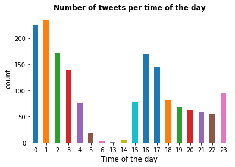

```python
fig, ax = plt.subplots()
only_dog_clean['hour'].value_counts(sort=False).plot(kind='bar')
ax.set_title('Number of tweets per time of the day', fontweight="bold")
ax.set_ylabel('count', fontsize=12)
ax.set_xlabel('Time of the day', fontsize=12)
plt.xticks(rotation='horizontal')
ax.spines['right'].set_visible(False)
ax.spines['top'].set_visible(False)
```

#### Observation:

There were no tweets fron 7:00 to 13:00 and only few contable tweets from 5:00 to 7:00 (May be Sleeping Time)

Twitter Account consistently made higher number of tweets during midnight ie: from 23:00 to 03:00. Highest number of tweets on average were 236 at 1:00 to 2:00 Night.

##### Most Active Month

```python
only_dog_clean.month.value_counts()
```

```
December     340
November     271
January      200
February     156
March        151
July         124
June         110
May           84
April         84
October       60
September     57
August        48
Name: month, dtype: int64
```

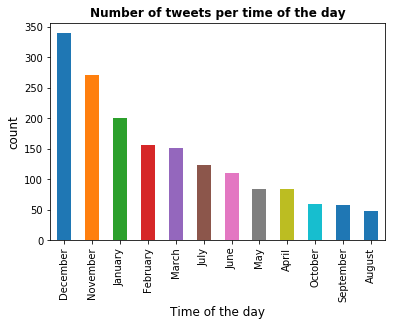

```python
#Bar Chart

fig, ax = plt.subplots()
only_dog_clean['month'].value_counts().plot(kind='bar')

ax.set_title('Number of tweets per time of the day', fontweight="bold")

ax.set_ylabel('count', fontsize=12)
ax.set_xlabel('Time of the day', fontsize=12)

plt.xticks(rotation='vertical')
```

#### Observation

This Twitter account was more active in Winters than Summer.

340 Tweets were made in December alone which is more than 10 tweets per day on average compared to 50 tweets in August on an average!

##### Most Active Day of Week

```python
only_dog_clean.weekday.value_counts()
```

```
Monday       280
Thursday     247
Tuesday      244
Friday       242
Wednesday    241
Sunday       222
Saturday     209
Name: weekday, dtype: int64
```

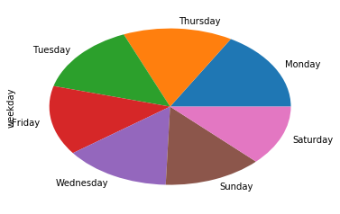

```python
#Pie Chart
only_dog_clean.weekday.value_counts().plot(kind='pie')
```

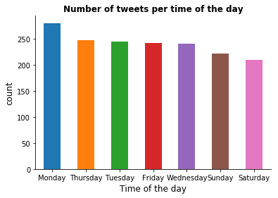

```python
#Bar Chart
fig, ax = plt.subplots()
only_dog_clean['weekday'].value_counts(sort=True).plot(kind='bar')
ax.set_title('Number of tweets per time of the day', fontweight="bold")
ax.set_ylabel('count', fontsize=12)
ax.set_xlabel('Time of the day', fontsize=12)
plt.xticks(rotation='horizontal')
ax.spines['right'].set_visible(False)
ax.spines['top'].set_visible(False)
```

#### Observation:

Most of the tweets were on Weekdays rather than Weekends.

##### Most Active Day

```python
only_dog_clean.date.value_counts()
```

```
25    68
23    64
17    64
28    64
8     61
29    60
21    59
20    58
16    58
24    57
18    57
3     56
4     56
5     56
2     55
```

[output cut: 17 more lines]

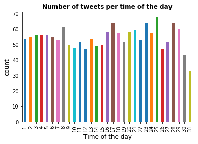

```python
fig, ax = plt.subplots()
only_dog_clean['date'].value_counts(sort=False).plot(kind='bar')
ax.set_title('Number of tweets per time of the day', fontweight="bold")
ax.set_ylabel('count', fontsize=12)
ax.set_xlabel('Time of the day', fontsize=12)
plt.xticks(rotation='vertical')
ax.spines['right'].set_visible(False)
ax.spines['top'].set_visible(False)
```

#### Observation :

There no common trend observed from the chart, Tweets were even distributed throught the days.

On an Average there are 68-33 Tweets per day.

##### Most Popular Dog Stage

```python
only_dog_clean.dog_stage.value_counts()/len(only_dog_clean)*100
```

```
None             84.569733
pupper            9.970326
doggo             3.204748
puppo             1.246291
doggo,pupper      0.474777
floofer           0.415430
doggo,floofer     0.059347
doggo,puppo       0.059347
Name: dog_stage, dtype: float64
```

#### Observation:

Although we have 85 percent missing Data for Dog current Stages,

As per Available data 10 percent of Dogs are Pupper and seems popular choice.Next we have Doggo and Puppo in the List.We have few floofer in the list too.

##### Most Popular Dog Name

```python
only_dog_clean.name.value_counts()[1:6,]
```

```
Charlie    10
Cooper     10
Lucy       10
Oliver      9
Tucker      9
Name: name, dtype: int64
```

#### Observation:

Among available data and Excuding all those invalid Names, Cooper,Lucy,Charlie are among most popular choices for Dog names.Next most popular dog's names are Oliver , Tucker.

If you want your dog's name to be different from others Please dont name him Cooper !